# ST558 Project 1

Shaoyu Wang

2022-09-14

## Data Processing

### First teps

Read in one section of the data using the code below:

```r
library(tidyverse)
library(readr)
sheet1 <- read_csv("https://www4.stat.ncsu.edu/~online/datasets/EDU01a.csv")
```

1. Select only the following columns:
- `Area_name` (rename as `area_name`)
- `STCOU`
- Any column that ends in “D”

```r
sheet2 <- sheet1 %>%
  rename(area_name = Area_name) %>%
  select(area_name, STCOU, ends_with("D"))
```

2. Convert the data into long format where each row has only one enrollment value for that `Area_name`.

```r
sheet3 <- sheet2 %>%
  pivot_longer(cols = 3:12, names_to = "EDU", values_to = "enrollment_value")
```

3. One of the new columns should now correspond to the old column names that end with a “D”. All columns in these census data files will have this similar format. The first three characters represent the survey with the next four representing the type of value you have from that survey. The last two digits prior to the “D” represent the year of the measurement. For more about the variables see [the data information sheet](https://www4.stat.ncsu.edu/~online/datasets/Mastdata.xls).
- Parse the string to pull out the year and convert the year into a **numeric** value such as 1997 or 2002.

```r
dates <- as.Date(substr(sheet3$EDU, start = 8, stop = 9), "%y")
yr <- as.numeric(format(dates, "%Y"))
sheet4 <- sheet3 %>% mutate(year = yr)
```

- Grab the first three characters and following four digits to create a new variable representing which measurement was grabbed.

```r
mysheet <- sheet4 %>%
  mutate(survey = substr(sheet4$EDU, start = 1, stop = 7))
```

4. Create two data sets
- one data set that contains only non-county data

```r
county_num <- grep(pattern = ", \\w\\w", mysheet$area_name)
noncounty_data <- mysheet %>% filter(!(row_number() %in% county_num))
```

- one data set that contains only county level data

```r
county_data <- mysheet %>% filter(row_number() %in% county_num)
```

For the county level data, add a `class` to the tibble called `county`.

```r
class(county_data) <- c("county", class(county_data))
```

Similarly, add a `class` to the non-county data called `state`.

```r
class(noncounty_data) <- c("state", class(noncounty_data))
```

5. For the county level tibble, create a new variable that describes which state one of these county measurements corresponds to (the two digit abbreviation is fine, see `substr()`).

```r
county_data %>%
  mutate(state = substr(county_data$area_name,
                        nchar(county_data$area_name)-1,
                        nchar(county_data$area_name)))
```

| area_name | STCOU | EDU | enrollment_value | year | survey | state |
| --- | --- | --- | --- | --- | --- | --- |
| Autauga, AL | 01001 | EDU010187D | 6829 | 1987 | EDU0101 | AL |
| Autauga, AL | 01001 | EDU010188D | 6900 | 1988 | EDU0101 | AL |
| Autauga, AL | 01001 | EDU010189D | 6920 | 1989 | EDU0101 | AL |
| Autauga, AL | 01001 | EDU010190D | 6847 | 1990 | EDU0101 | AL |
| Autauga, AL | 01001 | EDU010191D | 7008 | 1991 | EDU0101 | AL |
| Autauga, AL | 01001 | EDU010192D | 7137 | 1992 | EDU0101 | AL |
| Autauga, AL | 01001 | EDU010193D | 7152 | 1993 | EDU0101 | AL |
| Autauga, AL | 01001 | EDU010194D | 7381 | 1994 | EDU0101 | AL |
| Autauga, AL | 01001 | EDU010195D | 7568 | 1995 | EDU0101 | AL |
| Autauga, AL | 01001 | EDU010196D | 7834 | 1996 | EDU0101 | AL |

[output cut: 9990 more lines]

6. For the non-county level tibble, create a new variable called “division” corresponding to the state’s classification of division [here](https://en.wikipedia.org/wiki/List_of_regions_of_the_United_States). If row corresponds to a non-state (i.e. UNITED STATES), return ERROR for the division. The code for this part will not be a ton of fun but can be made easier with the use of %in%.

```r
division1 <- c("CONNECTICUT", "MAINE", "MASSACHUSETTS", "NEW HAMPSHIRE", "RHODE ISLAND", "VERMONT")
division2 <- c("NEW JERSEY", "NEW YORK", "PENNSYLVANIA")
division3 <- c("ILLINOIS", "INDIANA", "MICHIGAN", "OHIO", "WISCONSIN")
division4 <- c("IOWA", "KANSAS", "MINNESOTA", "MISSOURI", "NEBRASKA", "NORTH DAKOTA", "SOUTH DAKOTA")
division5 <- c("DELAWARE", "FLORIDA", "GEORGIA", "MARYLAND", "NORTH CAROLINA", "SOUTH CAROLINA", "VIRGINIA", "DISTRICT OF COLUMBIA", "District of Columbia", "WEST VIRGINIA")
division6 <- c("ALABAMA", "KENTUCKY", "MISSISSIPPI", "TENNESSEE")
division7 <- c("ARKANSAS", "LOUISIANA", "OKLAHOMA", "TEXAS")
division8 <- c("ARIZONA", "COLORADO", "IDAHO", "MONTANA", "NEVADA", "NEW MEXICO", "UTAH", "WYOMING")
division9 <- c("ALASKA", "CALIFORNIA", "HAWAII", "OREGON", "WASHINGTON")
noncounty_data %>%
  mutate(division =
     if_else (area_name == "UNITED STATES", "ERROR",
     if_else (area_name %in% division1, "New England",
     if_else (area_name %in% division2, "Mid-Atlantic",
     if_else (area_name %in% division3, "East North Central",
     if_else (area_name %in% division4, "West North Central",
     if_else (area_name %in% division5, "South Atlantic",
     if_else (area_name %in% division6, "East South Central",
     if_else (area_name %in% division7, "West South Central",
     if_else (area_name %in% division8, "Mountain",
     if_else (area_name %in% division9, "Pacific", "NA")))))))))))
```

| area_name | STCOU | EDU | enrollment_value | year | survey | division |
| --- | --- | --- | --- | --- | --- | --- |
| UNITED STATES | 00000 | EDU010187D | 40024299 | 1987 | EDU0101 | ERROR |
| UNITED STATES | 00000 | EDU010188D | 39967624 | 1988 | EDU0101 | ERROR |
| UNITED STATES | 00000 | EDU010189D | 40317775 | 1989 | EDU0101 | ERROR |
| UNITED STATES | 00000 | EDU010190D | 40737600 | 1990 | EDU0101 | ERROR |
| UNITED STATES | 00000 | EDU010191D | 41385442 | 1991 | EDU0101 | ERROR |
| UNITED STATES | 00000 | EDU010192D | 42088151 | 1992 | EDU0101 | ERROR |
| UNITED STATES | 00000 | EDU010193D | 42724710 | 1993 | EDU0101 | ERROR |
| UNITED STATES | 00000 | EDU010194D | 43369917 | 1994 | EDU0101 | ERROR |
| UNITED STATES | 00000 | EDU010195D | 43993459 | 1995 | EDU0101 | ERROR |
| UNITED STATES | 00000 | EDU010196D | 44715737 | 1996 | EDU0101 | ERROR |

[output cut: 520 more lines]

### Requirements

Now we want to repeat the above process for the 2nd component of the data set. This is available at the link below and can be read in by modifying the `read_csv()` code given earlier.

```r
data1 <- read_csv("https://www4.stat.ncsu.edu/~online/datasets/EDU01b.csv")
```

Rather than copying and pasting a bunch of stuff and changing things here and there, we want to write functions that do the above pieces and one function that we can call to do it all!

- Write one function that does steps 1 & 2 above. Give an optional argument (that is it has a default value) that allows the user to specify the name of the column representing the value (enrollment for these data sets).

```r
selectVar <- function(input) {
  data2 <- input %>%
  rename(area_name = Area_name) %>%
  select(area_name, STCOU, ends_with("D"))
  selected_data <- data2 %>%
  pivot_longer(cols = 3:12, names_to = "EDU", values_to = "enrollment_value")

  return(selected_data)
}

selected_data <- selectVar(data1)
```

- Write another function that takes in the output of step 2 and does step 3 above.

```r
numVar <- function(input) {
  dates <- as.Date(substr(input$EDU, start = 8, stop = 9), "%y")
  yr <- as.numeric(format(dates, "%Y"))
  num_data <- input %>% mutate(year = yr)
  return(num_data)
}

num_data <- numVar(selected_data)
```

- Write a function to do step 5

```r
selectCounty <- function(input) {
  county_level <- input %>%
    mutate(state = substr(input$area_name,
                          nchar(input$area_name)-1,
                          nchar(input$area_name)))
  return(county_level)
}

county_level <- selectCounty(num_data)
```

- Write a function to do step 6

```r
selectNonCounty <- function(input) {
  division1 <- c("CONNECTICUT", "MAINE", "MASSACHUSETTS", "NEW HAMPSHIRE", "RHODE ISLAND", "VERMONT")
  division2 <- c("NEW JERSEY", "NEW YORK", "PENNSYLVANIA")
  division3 <- c("ILLINOIS", "INDIANA", "MICHIGAN", "OHIO", "WISCONSIN")
  division4 <- c("IOWA", "KANSAS", "MINNESOTA", "MISSOURI", "NEBRASKA", "NORTH DAKOTA", "SOUTH DAKOTA")
  division5 <- c("DELAWARE", "FLORIDA", "GEORGIA", "MARYLAND", "NORTH CAROLINA", "SOUTH CAROLINA", "VIRGINIA", "DISTRICT OF COLUMBIA", "District of Columbia", "WEST VIRGINIA")
  division6 <- c("ALABAMA", "KENTUCKY", "MISSISSIPPI", "TENNESSEE")
  division7 <- c("ARKANSAS", "LOUISIANA", "OKLAHOMA", "TEXAS")
  division8 <- c("ARIZONA", "COLORADO", "IDAHO", "MONTANA", "NEVADA", "NEW MEXICO", "UTAH", "WYOMING")
  division9 <- c("ALASKA", "CALIFORNIA", "HAWAII", "OREGON", "WASHINGTON")
noncounty_level <- input %>%
  mutate(division =
     if_else (area_name == "UNITED STATES", "ERROR",
     if_else (area_name %in% division1, "New England",
     if_else (area_name %in% division2, "Mid-Atlantic",
     if_else (area_name %in% division3, "East North Central",
     if_else (area_name %in% division4, "West North Central",
     if_else (area_name %in% division5, "South Atlantic",
     if_else (area_name %in% division6, "East South Central",
     if_else (area_name %in% division7, "West South Central",
     if_else (area_name %in% division8, "Mountain",
     if_else (area_name %in% division9, "Pacific", "NA")))))))))))
  return(noncounty_level)
}

noncounty_level <- selectNonCounty(num_data)
```

- Write another function that takes in the output from step 3 and creates the two tibbles in step 4, calls the above two functions (to perform steps 5 and 6), and returns two final tibbles.

```r
createTwoData <- function(input) {
  county_num <- grep(pattern = ", \\w\\w", input$area_name)
  noncounty_data <- input %>% filter(!(row_number() %in% county_num))
  county_data <- input %>% filter((row_number() %in% county_num))

  county_level <- selectCounty(county_data)
  noncounty_level <- selectNonCounty(noncounty_data)
  class(county_data) <- c("county", class(county_data))
  class(noncounty_data) <- c("state", class(noncounty_data))

  return(list(county_level, noncounty_level))
}

two_tibble <- createTwoData(num_data)
county_level <- two_tibble[1]
#county_level
noncounty_level <- two_tibble[2]
#noncounty_level
```

Now last thing, put it all into one function call! This is called creating a [wrapper](https://en.wikipedia.org/wiki/Wrapper_function#:~:text=A%20wrapper%20function%20is%20a,little%20or%20no%20additional%20computation.) function. Create a function that takes in the URL of a .csv file in this format and the optional argument for the variable name, calls the functions you wrote above, and then returns the two tibbles.

```r
my_wrapper <- function(url, default_var_name = "default of some kind") {
  #a <- read_csv_code(...)
  readdata <- read_csv(url)
  #b <- function_for_step_1_2(a, ...)
  selectdata <- selectVar(readdata)
  #c <- function_for_step_3(b, ...)
  changeyear <- numVar(selectdata)
  #d <- function_for_steps4_5_6(c, ...) (where this function calls the other functions mentioned
  twoTibbles <- createTwoData(changeyear)
  #return final result
  return(twoTibbles)
}

result <- my_wrapper("https://www4.stat.ncsu.edu/~online/datasets/EDU01b.csv")
county_data <- result[1]
noncounty_data <- result[2]
```

## Call It and Combine Your Data

Call the function you made two times to read in and parse the two .csv files mentioned so far. Be sure to call the new value column the same in both function calls.

```r
result_a <- my_wrapper("https://www4.stat.ncsu.edu/~online/datasets/EDU01a.csv")
result_b <- my_wrapper("https://www4.stat.ncsu.edu/~online/datasets/EDU01b.csv")
```

Write a small function that takes in the results of two calls to your wrapper function and combines the tibbles appropriately (that is the two county level data sets get combined and the two non-county level data sets get combined). This can easily be done using `dplyr::bind_rows()`.

```r
combineTwoData <- function(input_a, input_b) {
  county_data_a <- input_a[1]
  noncounty_data_a <- input_a[2]
  county_data_b <- input_b[1]
  noncounty_data_b <- input_b[2]
  county_combined <- dplyr::bind_rows(county_data_a, county_data_b)
  noncounty_combined <- dplyr::bind_rows(noncounty_data_a, noncounty_data_b)
  return(list(county_combined, noncounty_combined))
}

combined <- combineTwoData(result_a, result_b)
twoCounty <- combined[1]
twoNonCounty <- combined[2]
```

## Write a Generic Function for Summarizing

### First steps

For the `state` plotting method, let’s write a function that plots the mean value of the statistic (enrollment for this data set) across the years for each `Division`. That is, on the x-axis we want the numeric year value, on the y-axis we want the mean of the statistic for each Division and numeric year. Also, we want to remove observations at the `ERROR` setting of `Division`. Let me help you out since we haven’t covered plotting (make sure you have loaded the `tidyverse`).

```r
plot.state <- function(input) {
  new_input <- do.call(rbind.data.frame, input)
  new_data <- new_input %>%
    select(division, year, enrollment_value) %>%
    group_by(division, year) %>%
    filter(division != "ERROR") %>%
    summarize(mean_of_stats = mean(enrollment_value))
  ggplot(new_data, aes(x = year, y = mean_of_stats, color = division)) +
    geom_line()
}
```

Test out this function by running `plot(_class_state_df_here_, var_name = ...)`. (This doesn’t need to go into the report here, just make sure it is working!)

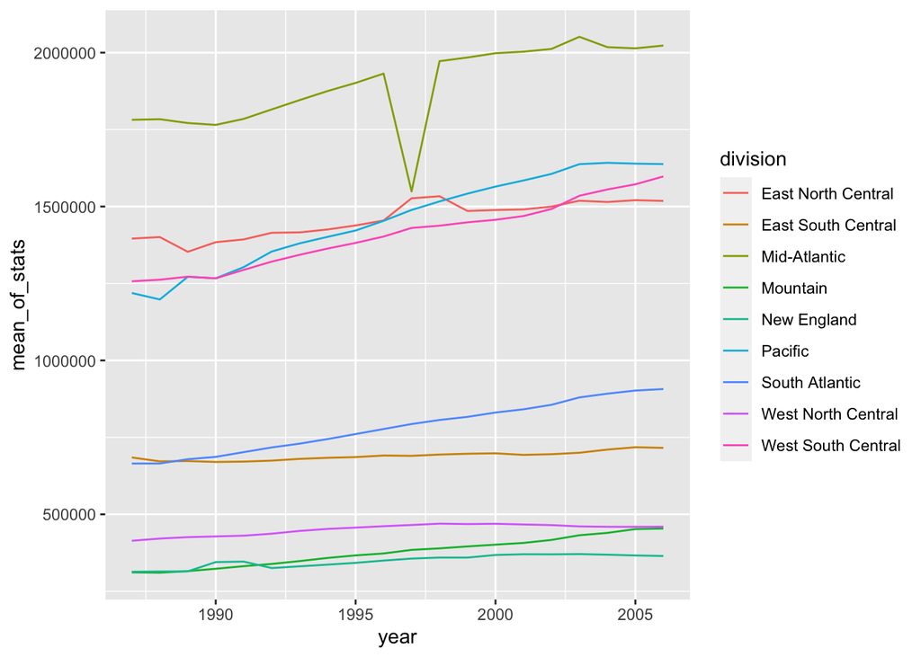

```r
plot.state(twoNonCounty)
```

For the class `county` we’ll do a similar plotting function but with more flexibility. This function should allow the user to: - specify the state of interest, giving a default value if not specified - determine whether the ‘top’ or ‘bottom’ most counties should be looked at with a default for ‘top’ - instruct how many of the ‘top’ or ‘bottom’ will be investigated with a default value of 5

Within your plot function you should:

- filter the data to only include data from the state specified
- find the overall mean of the statistic (use `get(var_name)` here as well) for each `Area_name` and sort those values from largest to smallest if ‘top’ is specified or smallest to largest if ‘bottom’ is specified
- obtain the top or bottom x number of `Area_names` from the previous step where x is given by the user or the default
- filter the data for this state to only include the `Area_name`’s from the previous part (this is the data we’ll use to plot)
- use the plot code here to create a line plot:

```r
plot.county <- function(input, state_name="NC", size = 5) {
  new_input <- do.call(rbind.data.frame, input)
  sort_data <- new_input %>%
    filter(state == state_name) %>%
    group_by(area_name) %>%
    summarize(mean_of_stats = mean(enrollment_value)) %>%
    top_n(size, mean_of_stats)

  new_data <- new_input %>%
    filter(area_name %in% sort_data$area_name)
  ggplot(new_data, aes(x = year, y = enrollment_value, color = area_name)) +
    geom_line()
}
```

Notice we aren’t plotting the means here, the actual statistic’s value. Test out this function by running `plot(_class_county_df_here_)`. Run it a few more times specifying different input arguments.

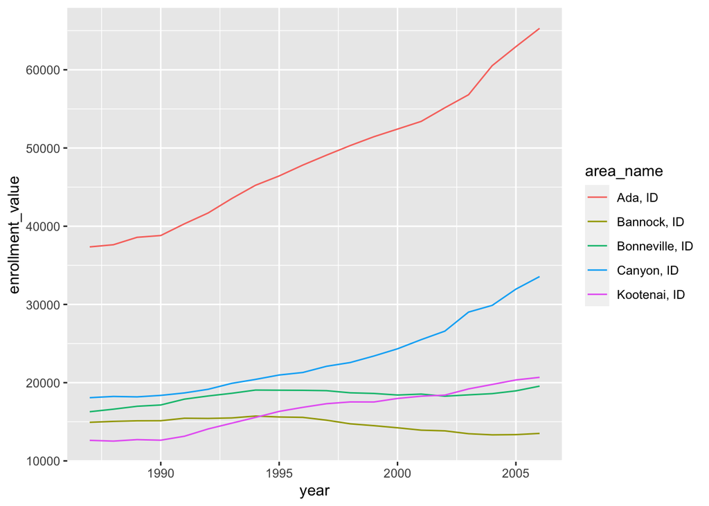

```r
plot.county(twoCounty, state_name = "ID", size = 5)
```

## Put it Together

The end of your report should have a section where you do the following:

- Run your data processing function on the two enrollment URLs given previously, specifying an appropriate name for the enrollment data column.

```r
result_a <- my_wrapper("https://www4.stat.ncsu.edu/~online/datasets/EDU01a.csv")
result_b <- my_wrapper("https://www4.stat.ncsu.edu/~online/datasets/EDU01b.csv")
```

- Run your data combining function to put these into one object (with two data frames)

```r
result_ab <- combineTwoData(result_a, result_b)
county_combined <- result_ab[1]
noncounty_combined <- result_ab[2]
```

- Use the plot function on the state data frame

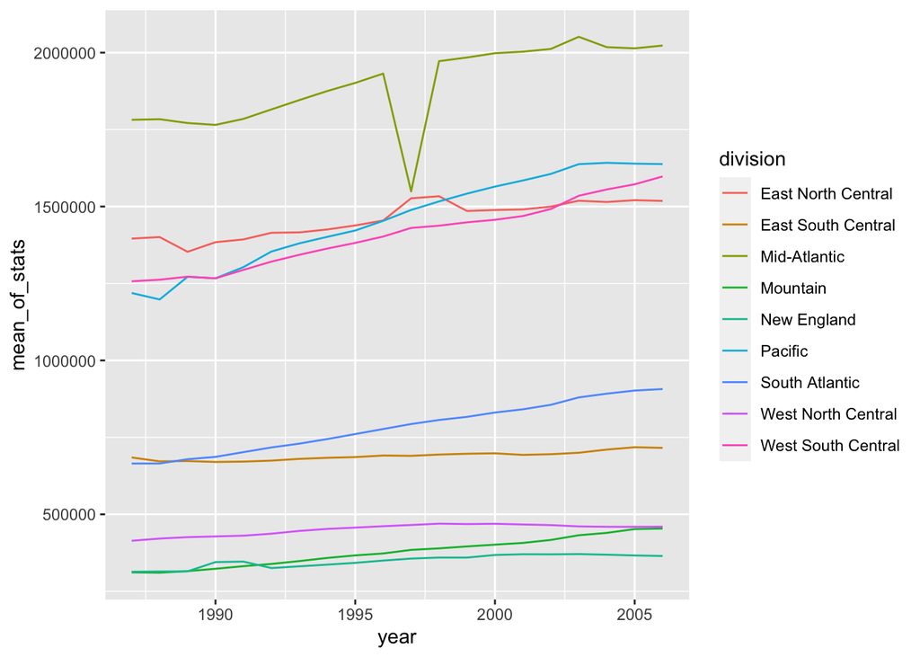

```r
plot.state(noncounty_combined)
```

- Use the plot function on the county data frame
  - Once specifying the state to be “PA”, the group being the top, the number looked at being 7
  - Once specifying the state to be “PA”, the group being the bottom, the number looked at being 4
  - Once without specifying anything (defaults used)
  - Once specifying the state to be “MN”, the group being the top, the number looked at being 10

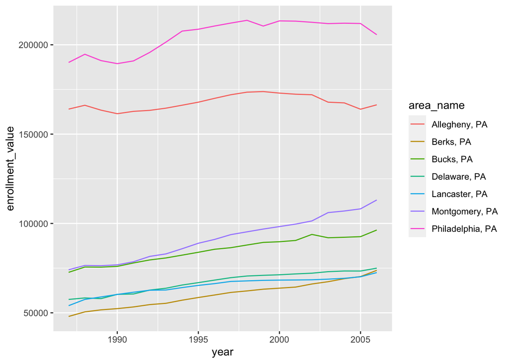

```r
plot.county(county_combined, state_name = "PA", size = 7)
```

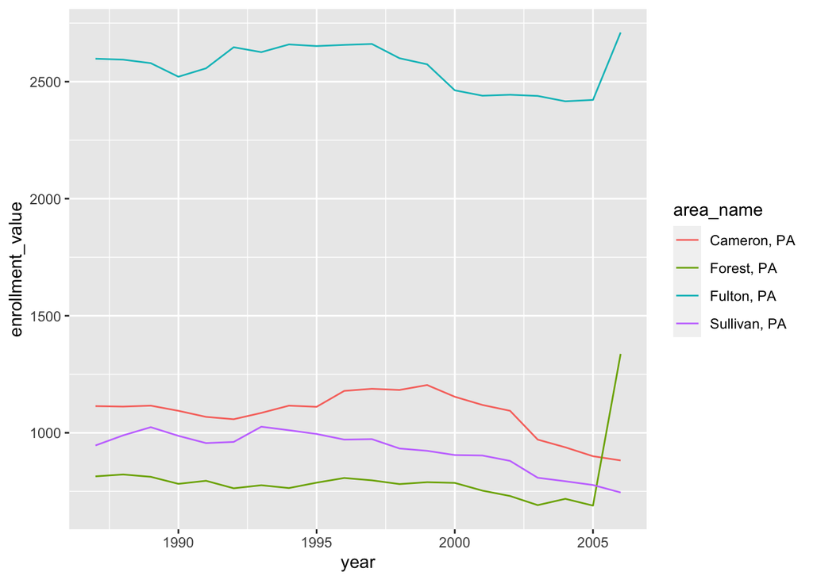

```r
plot.county(county_combined, state_name = "PA", size = -4)
```

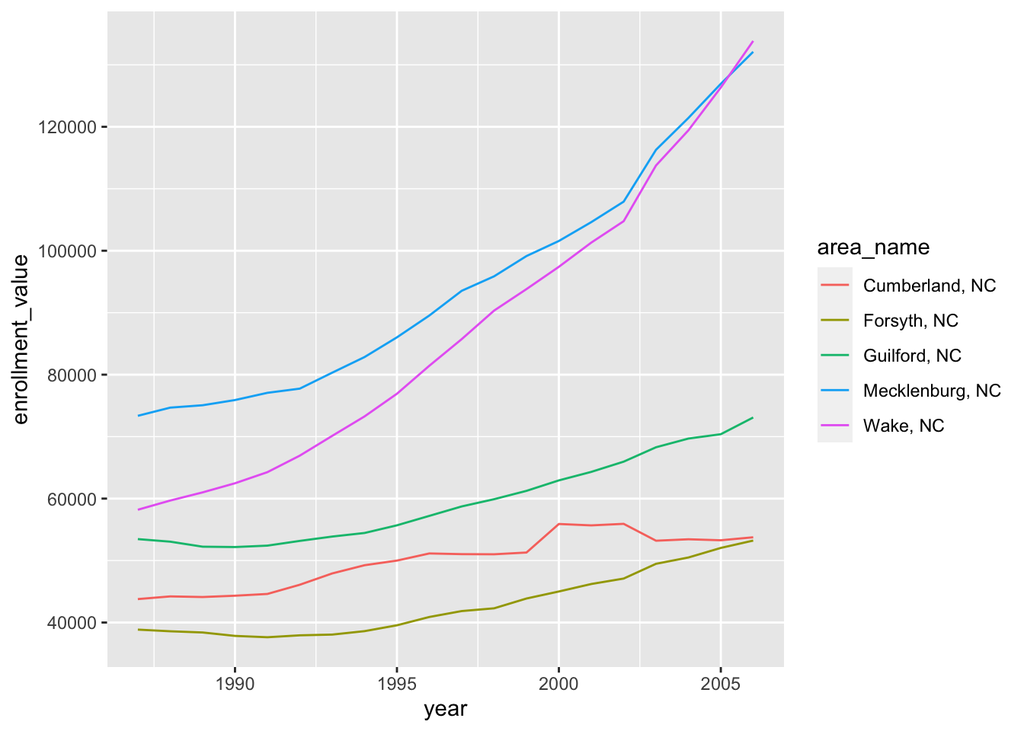

```r
plot.county(county_combined)
```

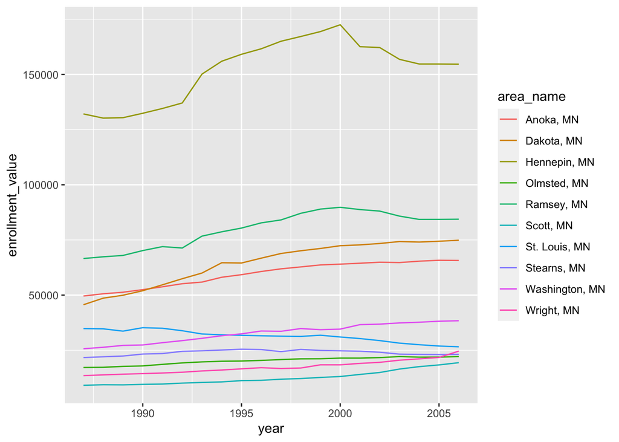

```r
plot.county(county_combined, state_name = "MN", size = 10)
```

Lastly, we’ll read in another similar data set and apply our functions!

- Run your data processing function on the four data sets at URLs given below:
  - https://www4.stat.ncsu.edu/~online/datasets/PST01a.csv
  - https://www4.stat.ncsu.edu/~online/datasets/PST01b.csv
  - https://www4.stat.ncsu.edu/~online/datasets/PST01c.csv
  - https://www4.stat.ncsu.edu/~online/datasets/PST01d.csv

```r
PST_a <- my_wrapper("https://www4.stat.ncsu.edu/~online/datasets/PST01a.csv")
PST_b <- my_wrapper("https://www4.stat.ncsu.edu/~online/datasets/PST01b.csv")
PST_c <- my_wrapper("https://www4.stat.ncsu.edu/~online/datasets/PST01c.csv")
PST_d <- my_wrapper("https://www4.stat.ncsu.edu/~online/datasets/PST01d.csv")
```

- Run your data combining function (probably three times) to put these into one object (with two data frames)

```r
combined_ab <- combineTwoData(PST_a, PST_b)
combined_abc <- combineTwoData(combined_ab, PST_c)
combined_abcd <- combineTwoData(combined_abc, PST_d)
combined_county <- combined_abcd[1]
combined_noncounty <- combined_abcd[2]
```

- Use the plot function on the `state` data frame

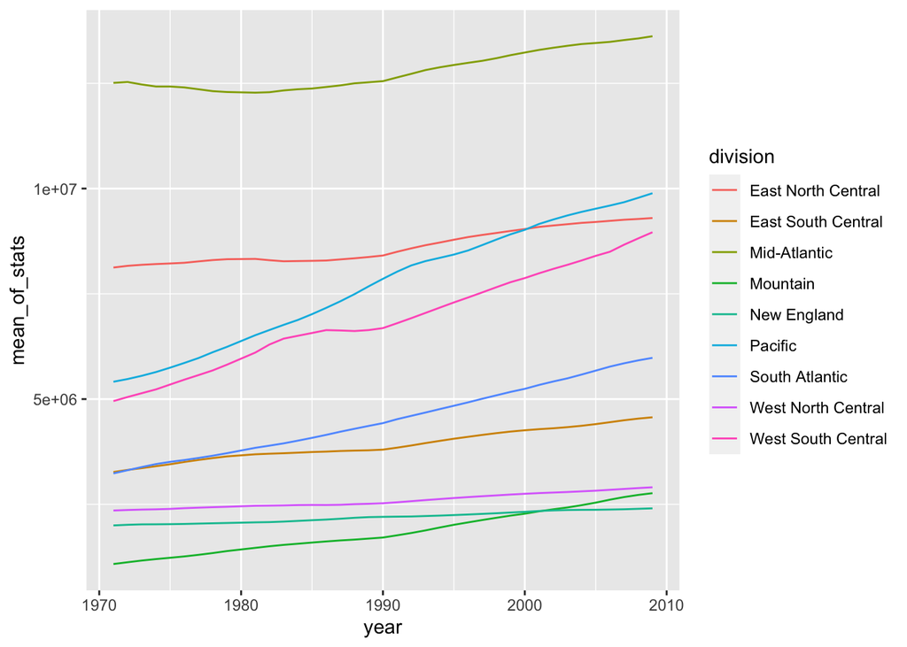

```r
plot.state(combined_noncounty)
```

- Use the plot function on the `county` data frame
  - Once specifying the state to be “CT”, the group being the top, the number looked at being 6
  - Once specifying the state to be “NC”, the group being the bottom, the number looked at being 10
  - Once without specifying anything (defaults used)
  - Once specifying the state to be “MN”, the group being the top, the number looked at being 4

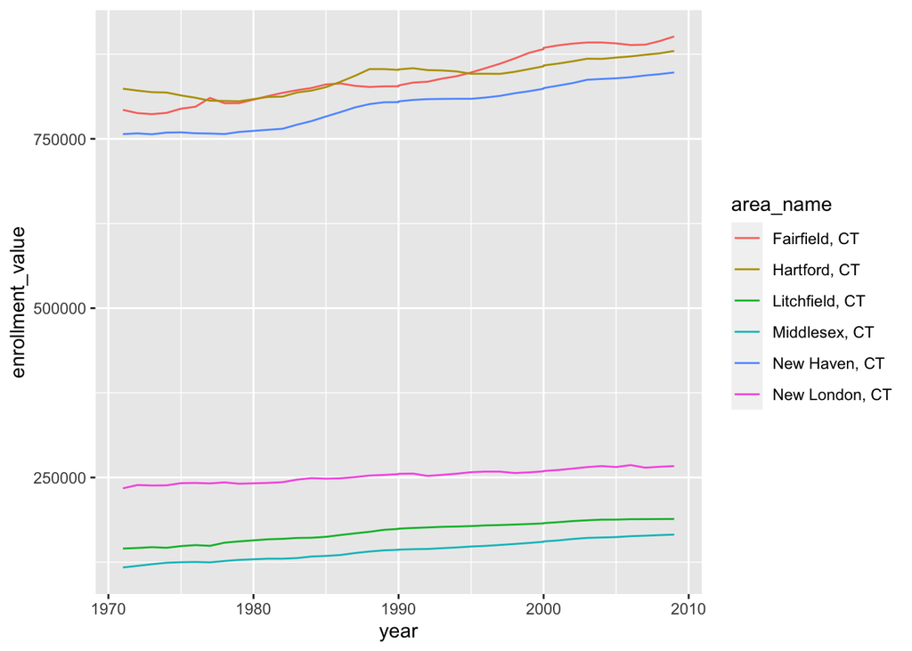

```r
plot.county(combined_county, state_name = "CT", size = 6)
```

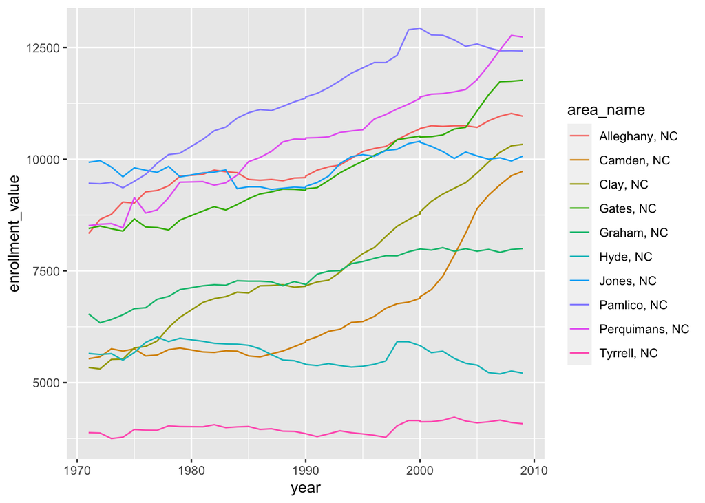

```r
plot.county(combined_county, state_name = "NC", size = -10)
```

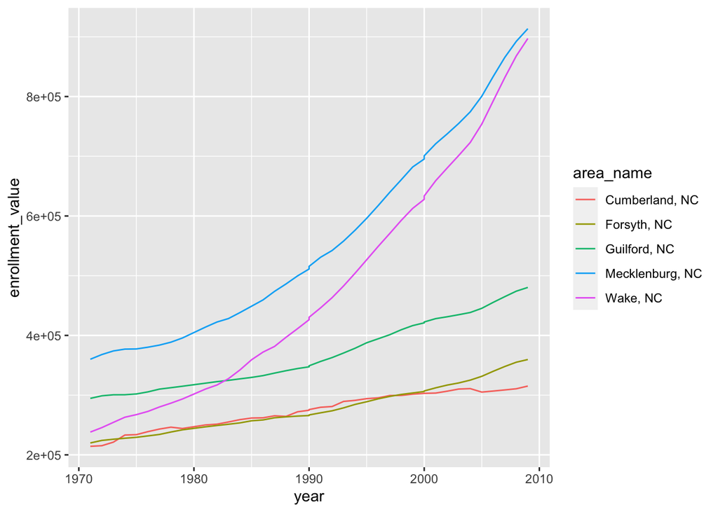

```r
plot.county(combined_county)
```

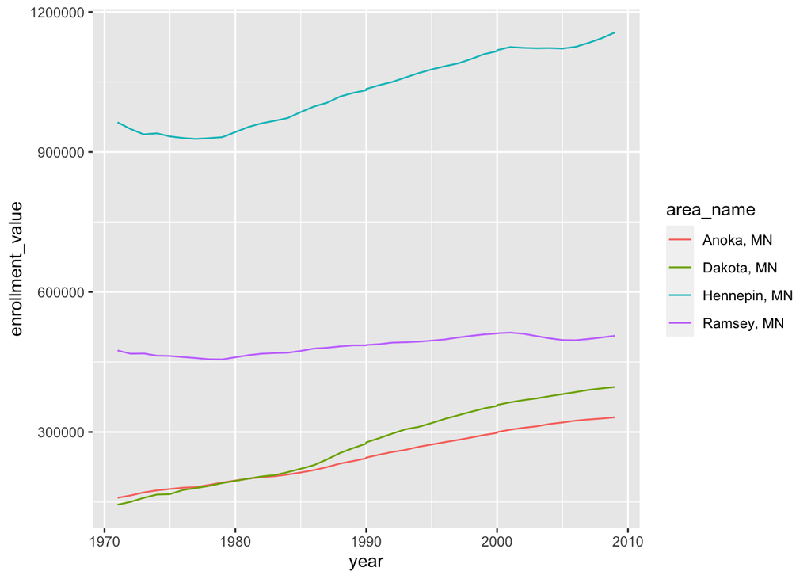

```r
plot.county(combined_county, state_name = "MN", size = 4)
```